# Simulation of popPK models

## About me

- Ruben Faelens
  - Belgian, living in Leuven
  - Just call me ‘Ruben’
- Computer Scientist, graduated 2010
- PK/PD modeling & simulation from 2012 onward
- Wrote *simulo*, a clinical trial simulation software
- Consultant for pharma industry from 2014 - 2018
- Working at *KULeuven* as PhD researcher
  - MI(MIPD)D: informed development of precision dosing tools
  - Paving the road towards precision dosing

## Simulation of pharmacometric models

[video not shown]

## Modeling & Simulation: why?

- Deeper understanding of the compound and mechanisms
- Predict candidate treatment
- Answer what-if scenario
- Predict candidate trial
- Optimize trial, minimize risk

## Model-informed drug development

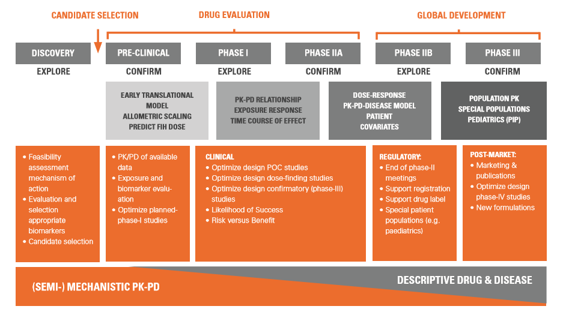

## What kind of questions can we address?

- What is the best dose and administration interval?
- What is the best sampling schedule?
- Which protocol design will we choose?
- How many subjects do I enrol in the next phase study?
- Which proportion of my population will be well treated?
- What is the best population targeted by the drug?
- Will you continue this drug development?
- Can we look at another dosage form?
- Having information on other doses, what is the mean effect of a 100mg dose after 2 weeks of treatment?
- What is the probability of success in phase III?

## Limitations

- Explain everything
- Give you the answer you want
- Find an effect where none exists
- Provide one “true” answer
- Make good studies unnecessary
- Make a silk purse out of a sow’s ear
- Make your decisions for you

## A structured approach

- Modeling
- Goodness of Fit
- Population simulation
- Probability of Technical Success
- Clinical trial simulation
- Probability of Study Success

## Hands-on

## Sunitinib

Sunitinib is a multi-targeted tyrosine kinase inhibitor used in the treatment of advanced renal cell carcinoma (RCC) and imatinib-resistant/intolerant gastrointestinal stromal tumors (GIST). It gained market access in 2006.

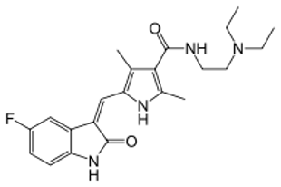

Khosravan et al Reza Khosravan et al. Population Pharmacokinetic/Pharmacodynamic Modeling of Sunitinib by Dosing Schedule in Patients with Advanced Renal Cell Carcinoma or Gastrointestinal Stromal Tumor. Clin Pharmacokinet (2016) 55:1251–1269 published a model predicting PK and several PD endpoints.

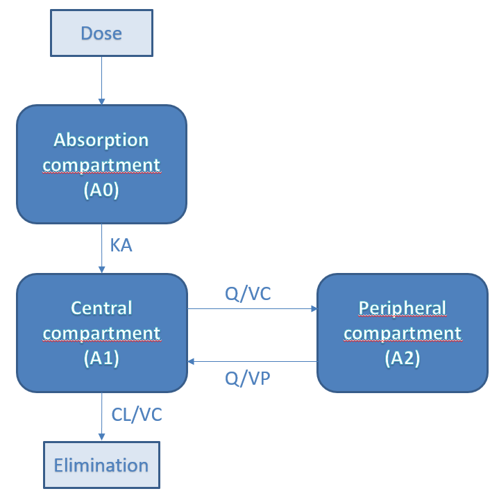

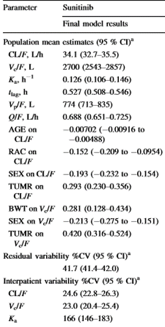

## Typical value simulations

These simulations predict a single profile using the typical value parameters

Dose (mg)

Number of doses

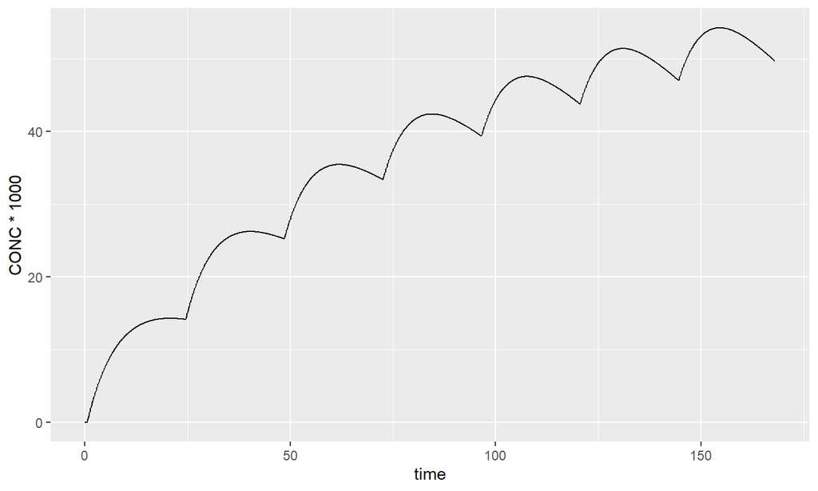